# Homework #6

**See Canvas for this assignment's due date**. Complete all of the following problems. Ideally, the theoretical problems should be answered in a Markdown cell directly underneath the question. If you don't know LaTex/Markdown, you may submit separate handwritten solutions to the theoretical problems. Please do not turn in messy work. Computational problems should be completed in this notebook (using the R kernel is preferred). Computational questions may require code, plots, analysis, interpretation, etc. Working in small groups is allowed, but it is important that you make an effort to master the material and hand in your own work.

## A. Theoretical Problems

### Problem A.1 (10 points)

Recall the following one-way ANOVA notation and assumptions:

- Assume that there are $J$ groups/levels, with $n_j$ units in each level ($j = 1,...,J$).
- The true mean of the $j^{th}$ group is denoted $\mu_j$.
- $Y_{i,j}$ is the response value for an individual in the $i^{th}$ group at the $j^{th}$ level (for a fixed $j$, $i = 1,...,n_j$)..
- $Y_{i,j} = \mu_j + \varepsilon_{i,j}$, where $\varepsilon_{i,j} \sim N(0,\sigma^2)$.
- $\bar{Y}_{\cdot,j}$ is the sample mean of all units in the $j^{th}$ level.

**Show that, for any set of constants $\mathbf{a} = (a_1,...,a_J)^T$, the quantity $\displaystyle \sum^J_{j=1}a_j\bar{Y}_{\cdot,j}$ is normally distributed with mean $\displaystyle \sum^J_{j=1}a_j\mu_j$ and variance $\displaystyle \sigma^2\sum^J_{j=1}a^2_j\big/n_j$.**

$$ E[\sum^J_{j=1}a_j\bar{Y}_{\cdot,j}] = \sum^j_{j=1}a_jE[\bar{Y}_{.,j}] = \sum^j_{j=1}a_j\mu_j $$$$ Var(\sum^J_{j=1}a_j\bar{Y}_{\cdot,j}) = \sum^j_{j=1} a^2_jVar(\bar{Y}_{.,j}) = \sigma^2\sum^j_{j=1}\frac{a^2_j}{n_j} $$

### Problem A.2 (12 points, 3 points each)

This problem contains several True/False questions. **Please answer each using R code. Store your answer as a logical (either TRUE or FALSE, case sensitive) in a variable named for each part. So, for example, if part (a) were: 2+2 = 5. Your answer would be:**

```r
a = FALSE
```

#### (a) In order to run a one-way ANOVA in the regression context, the number of units in each group/level must be the same.

```r
a = FALSE
```

#### (b) Let $\mu_1,...,\mu_J$ be a set of group means and let $\mathbf{a} = (1,-1,0,...,0)^T$ be a set of $J$ constants. Then $\sum^J_{j=1}a_j\mu_j$ can be used to test the null hypothesis that $\mu_1 = \mu_2$.

```r
b = FALSE
```

#### (c) Consider the plot on the left in this [link](https://statmodeling.stat.columbia.edu/wp-content/uploads/2020/03/Screen-Shot-2020-03-15-at-5.45.37-PM.png). There is not a substantial interaction between age group and political party. (This [video](https://www.youtube.com/watch?v=JTm739f5hQs) might be a helpful resource.)

```r
c = TRUE
```

#### (d) If an interaction term in a two-way ANOVA model is significant, then one should not trust the estimates or interpretations of main effects alone.

```r
d = TRUE
```

## B. Computational Problems

### Problem B.1 (15 points)

#### For the teengamb data, fit a model with gamble as the response and ${\tt sex}$ and ${\tt income}$ as predictors. Call the model lmod_teengamb. Investigate the possibility of statistically significant interactions between these predictors. Store your final model--the one with or without interaction terms, depending on the outcome of your investigations--as lmod_final. Interpret the final model.

([Here's](https://rdrr.io/cran/faraway/man/teengamb.html) a description of the data.)

```r
teengamb = read.table("https://www.colorado.edu/amath/sites/default/files/attached-files/teengamb.txt",
          sep = "\t", header = TRUE)

summary(teengamb)
```

```
      sex             status          income           verbal
 Min.   :0.0000   Min.   :18.00   Min.   : 0.600   Min.   : 1.00
 1st Qu.:0.0000   1st Qu.:28.00   1st Qu.: 2.000   1st Qu.: 6.00
 Median :0.0000   Median :43.00   Median : 3.250   Median : 7.00
 Mean   :0.4043   Mean   :45.23   Mean   : 4.642   Mean   : 6.66
 3rd Qu.:1.0000   3rd Qu.:61.50   3rd Qu.: 6.210   3rd Qu.: 8.00
 Max.   :1.0000   Max.   :75.00   Max.   :15.000   Max.   :10.00
     gamble
 Min.   :  0.0
 1st Qu.:  1.1
 Median :  6.0
 Mean   : 19.3
 3rd Qu.: 19.4
 Max.   :156.0
```

```r
lmod_teengamb = lm(gamble ~ sex + income, teengamb)
summary(lmod_teengamb)
```

```
Call:
lm(formula = gamble ~ sex + income, data = teengamb)

Residuals:
    Min      1Q  Median      3Q     Max
-49.757 -11.649   0.844   8.659 100.243

Coefficients:
            Estimate Std. Error t value Pr(>|t|)
(Intercept)    4.041      6.394   0.632  0.53070
sex          -21.634      6.809  -3.177  0.00272 **
income         5.172      0.951   5.438 2.24e-06 ***
---
Signif. codes:  0 ‘***’ 0.001 ‘**’ 0.01 ‘*’ 0.05 ‘.’ 0.1 ‘ ’ 1

Residual standard error: 22.75 on 44 degrees of freedom
Multiple R-squared:  0.5014,	Adjusted R-squared:  0.4787
F-statistic: 22.12 on 2 and 44 DF,  p-value: 2.243e-07
```

```r
lmod_tnmb = lm(gamble ~ sex + income + sex:income, teengamb)
summary(lmod_tnmb)
```

```
Call:
lm(formula = gamble ~ sex + income + sex:income, data = teengamb)

Residuals:
    Min      1Q  Median      3Q     Max
-56.522  -4.860  -1.790   6.273  93.478

Coefficients:
            Estimate Std. Error t value Pr(>|t|)
(Intercept)  -2.6596     6.3164  -0.421  0.67580
sex           5.7996    11.2003   0.518  0.60724
income        6.5181     0.9881   6.597 4.95e-08 ***
sex:income   -6.3432     2.1446  -2.958  0.00502 **
---
Signif. codes:  0 ‘***’ 0.001 ‘**’ 0.01 ‘*’ 0.05 ‘.’ 0.1 ‘ ’ 1

Residual standard error: 20.98 on 43 degrees of freedom
Multiple R-squared:  0.5857,	Adjusted R-squared:  0.5568
F-statistic: 20.26 on 3 and 43 DF,  p-value: 2.451e-08
```

```r
lmod_final = lmod_tnmb
```

The final model requires the interaction model because the p-value for the interaction is signficant therefore we need the interaction model.

### Problem B.2

The `pulp` data frame has 20 rows and 2 columns. Data comes from an experiment to test the paper brightness depending on a shift operator. For this problem, set $\alpha = 0.05$.

**B.2 (a) [10 points] Determine whether there are any differences between the operators. Describe the fit of your model and the results.**

```r
library(tidyverse)
library(dplyr)

pulp = read.table("https://raw.githubusercontent.com/bzaharatos/-Statistical-Modeling-for-Data-Science-Applications/master/ANOVA%20and%20Experimental%20Design/Datasets/pulp.txt", sep = "")
head(pulp)
```

| bright | operator |
| --- | --- |
| 59.8 | a |
| 60.0 | a |
| 60.8 | a |
| 60.8 | a |
| 59.8 | a |
| 59.8 | b |

```
Call:
lm(formula = bright ~ operator, data = pulp)

Residuals:
   Min     1Q Median     3Q    Max
-0.440 -0.195 -0.070  0.175  0.560

Coefficients:
            Estimate Std. Error t value Pr(>|t|)
(Intercept)  60.2400     0.1458 413.243   <2e-16 ***
operatorb    -0.1800     0.2062  -0.873   0.3955
operatorc     0.3800     0.2062   1.843   0.0839 .
operatord     0.4400     0.2062   2.134   0.0486 *
---
Signif. codes:  0 ‘***’ 0.001 ‘**’ 0.01 ‘*’ 0.05 ‘.’ 0.1 ‘ ’ 1

Residual standard error: 0.326 on 16 degrees of freedom
Multiple R-squared:  0.4408,	Adjusted R-squared:  0.3359
F-statistic: 4.204 on 3 and 16 DF,  p-value: 0.02261
```

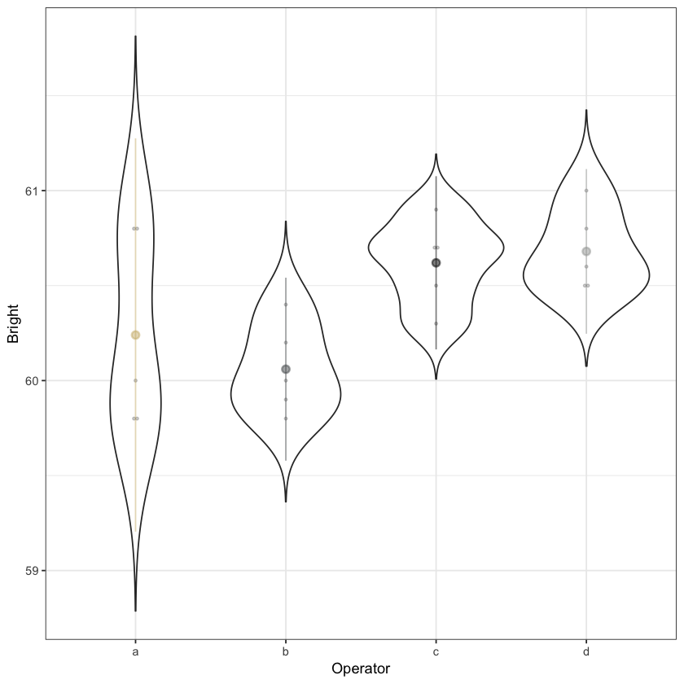

|  | Df | Sum Sq | Mean Sq | F value | Pr(>F) |
| --- | --- | --- | --- | --- | --- |
| operator | 3 | 1.34 | 0.4466667 | 4.203922 | 0.0226089 |
| Residuals | 16 | 1.70 | 0.1062500 | NA | NA |

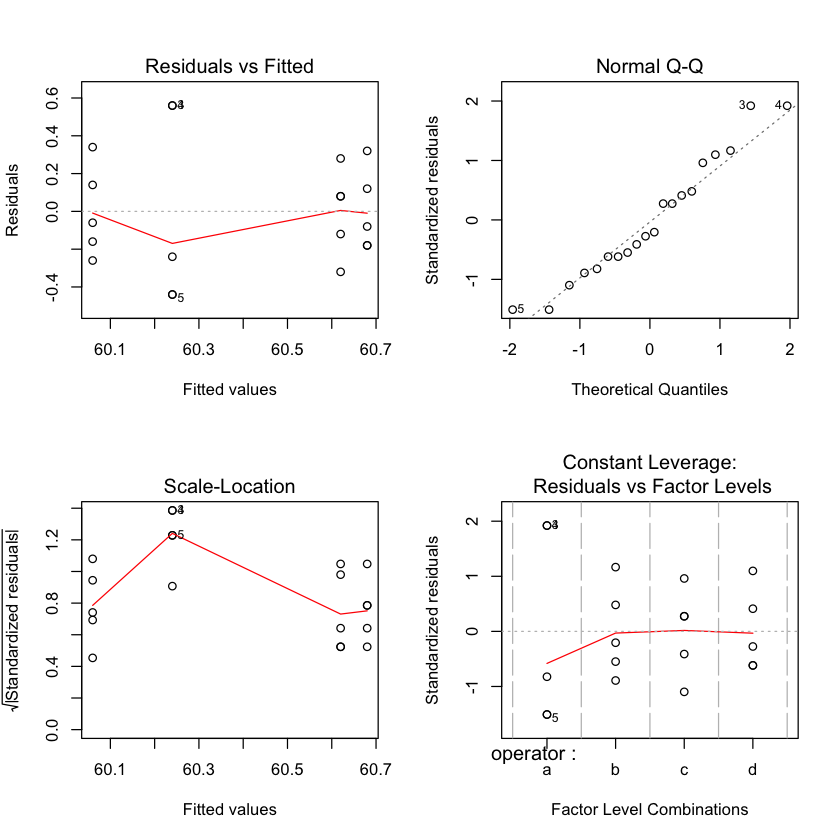

```r
library(ggplot2)
library(Hmisc)
summary(lm(bright~operator, pulp))

p = ggplot(pulp, aes(x = operator, y = bright)) + # + geom_boxplot(aes(x = group , y = weight))
    geom_violin(trim = FALSE) +
    #geom_boxplot(width = 0.1, alpha = 0.5, fill = c('#CFB87C', '#565A5C', "A2A4A3", 'blue')) +
    geom_dotplot(binaxis = 'y', stackdir = 'center', dotsize = 0.4, alpha = 0.2) +
    stat_summary(fun.data = mean_sdl, color = c('#CFB87C', '#565A5C', 'black', "#A2A4A3"), alpha = 0.5) +
    xlab("Operator") + ylab("Bright") +
    theme_bw();
p
par(mfrow = c(2,2))
plot(lm(bright~operator, pulp))
anova(lm(bright~operator, pulp))
```

Looking at the first plot, the sample mean for each level b,c, and d is encompassed in level a. Notice the normal Q-Q plot has three grouping of points; displaying a bit of nonlinearity. The residual vs fitted plots seem to show pattern meaning it has some nonconstant variance. Overall, we dont have enough evidence to show how well the plot is fitting but we do seem some violations.

**B.2 (b) [12 points] Conduct pairwise comparisons for each mean. Summarize your findings.**

```r
av=aov(lm(bright~operator, pulp))

TukeyHSD(av)
```

```
  Tukey multiple comparisons of means
    95% family-wise confidence level

Fit: aov(formula = lm(bright ~ operator, pulp))

$operator
     diff         lwr       upr     p adj
b-a -0.18 -0.76981435 0.4098143 0.8185430
c-a  0.38 -0.20981435 0.9698143 0.2903038
d-a  0.44 -0.14981435 1.0298143 0.1844794
c-b  0.56 -0.02981435 1.1498143 0.0657945
d-b  0.62  0.03018565 1.2098143 0.0376691
d-c  0.06 -0.52981435 0.6498143 0.9910783
```

Notice that all operators except `d-b` have lower bounds and upper bounds that cover zero therefore we evidence to accept the null. In addition, the p-values to all those operators are greater than the significant level. `d-b` on the otherhand has a p-values less than the significant level, $0.05$ and the lower and upper bounds that does not cover zero, ergo we can reject the null.

### Problem B.3

The National Institute of Diabetes and Digestive and Kidney Diseases conducted a study of 768 adult female Pima Indians living near Phoenix, AZ. The purpose of the study was the investigate factors related to diabetes.

*Before we analyze these data, we should note that some have raised ethical issues with its collection and popularity in the statistics and data science community. We should think seriously about these concerns. For example, Maya Iskandarani wrote a brief [piece](https://researchblog.duke.edu/2016/10/24/diabetes-and-privacy-meet-big-data/) on consent and privacy concerns raised by this dataset. After you familarize yourself with the data, we'll then turn to these ethical concerns.*

**B.3 (a) [8 points] Perform simple graphical and numerical summaries of the data. Can you find any obvious irregularities in the data? If so, take appropriate steps to correct these problems.**

```r
library(ggplot2)
library(dplyr)
pima = read.table("https://www.colorado.edu/amath/sites/default/files/attached-files/pima.txt",
                  sep = "\t", header = TRUE)

#Here's a description of the data: https://rdrr.io/cran/faraway/man/pima.html
```

[output not shown]

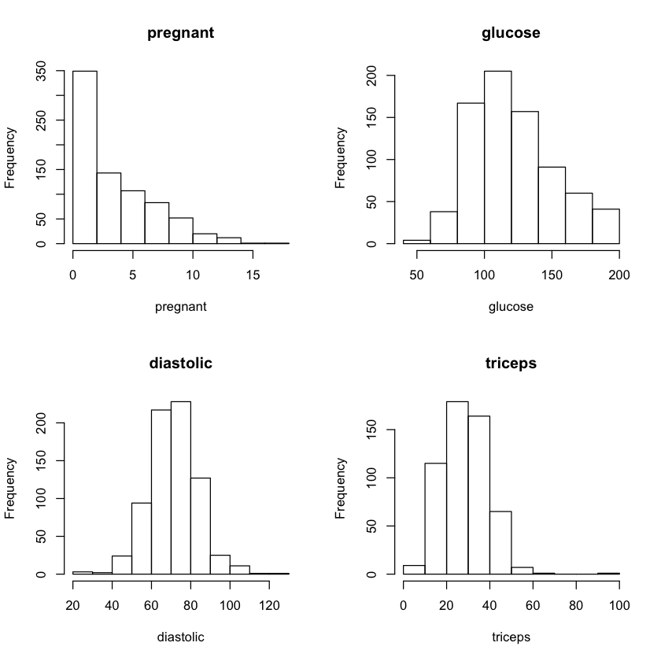

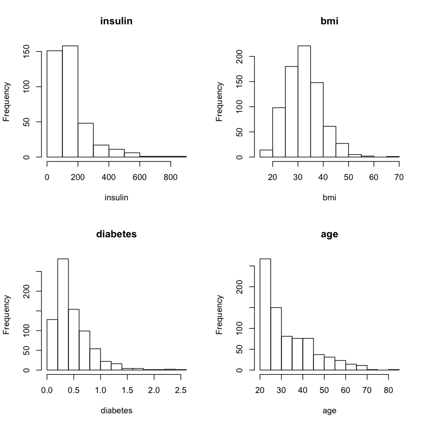

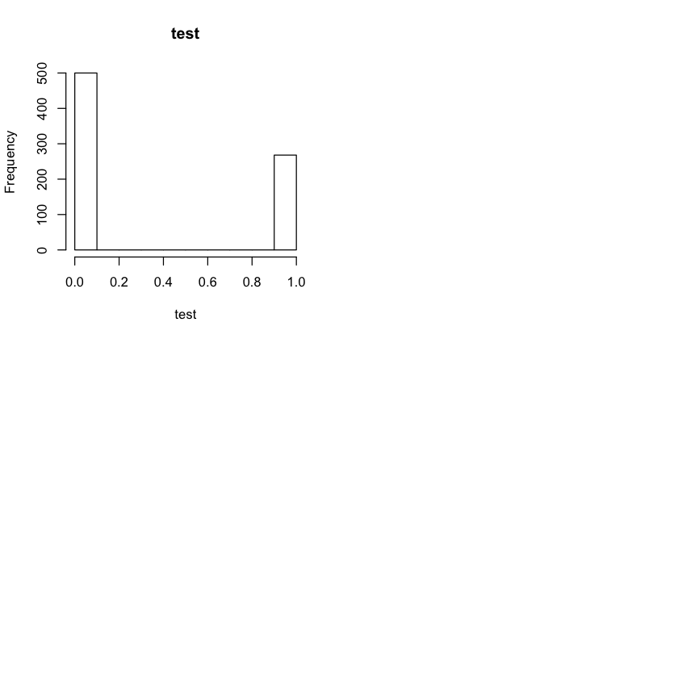

```r
library(corrplot)


#head(pima)
summary(pima)
par(mfrow = c(2,2))


for(i in 1:ncol(pima)){
    hist(pima[,i], main = colnames(pima)[i], xlab = colnames(pima)[i])
}

pima$glucose[pima$glucose == 0] = NA
pima$diastolic[pima$diastolic == 0] = NA
pima$triceps[pima$triceps == 0] = NA
pima$insulin[pima$insulin == 0] = NA
pima$bmi[pima$bmi == 0] = NA
```

**B.3 (b) [12 points] Fit a model with the result of the diabetes test as the response and all the other variables as predictors. Store this model as `glmod_pima`. Can you tell whether this model fits the data?**

```
Call:
glm(formula = test ~ ., family = "binomial", data = pima)

Deviance Residuals:
    Min       1Q   Median       3Q      Max
-2.7823  -0.6603  -0.3642   0.6409   2.5612

Coefficients:
              Estimate Std. Error z value Pr(>|z|)
(Intercept) -1.004e+01  1.218e+00  -8.246  < 2e-16 ***
pregnant     8.216e-02  5.543e-02   1.482  0.13825
glucose      3.827e-02  5.768e-03   6.635 3.24e-11 ***
diastolic   -1.420e-03  1.183e-02  -0.120  0.90446
triceps      1.122e-02  1.708e-02   0.657  0.51128
insulin     -8.253e-04  1.306e-03  -0.632  0.52757
bmi          7.054e-02  2.734e-02   2.580  0.00989 **
diabetes     1.141e+00  4.274e-01   2.669  0.00760 **
age          3.395e-02  1.838e-02   1.847  0.06474 .
---
Signif. codes:  0 ‘***’ 0.001 ‘**’ 0.01 ‘*’ 0.05 ‘.’ 0.1 ‘ ’ 1

(Dispersion parameter for binomial family taken to be 1)

    Null deviance: 498.10  on 391  degrees of freedom
Residual deviance: 344.02  on 383  degrees of freedom
  (376 observations deleted due to missingness)
AIC: 362.02

Number of Fisher Scoring iterations: 5
```

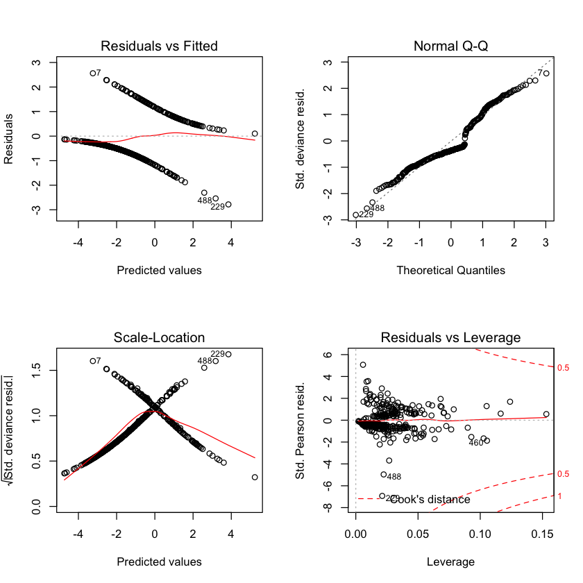

```r
glmod_pima = glm(test ~ ., data =pima, family = "binomial")
summary(glmod_pima)
par(mfrow = c(2,2))
plot(glmod_pima)
```

Using the tools that we normaly use for linear regressions would not help us for this binomial regression model due to the fact that binomials responses have probability of `0` and `1`. Therefore these graphs would not help us diagnost the model and conclude if it the model fits or not.

**B.3 (c) [14 points] Using the model above, write R code to calculate the difference in the odds of testing positive for diabetes for a woman with a BMI at the first quartile compared with a woman at the third quartile, assuming all other factors are held constant. Store your answer in a variable `x`. Also, give a confidence interval for this difference, stored in a variable `ci`.**

```r
bmiQ1 = quantile(pima$bmi, 0.25, na.rm = TRUE)
bmiQ3 = quantile(pima$bmi, 0.75, na.rm = TRUE)
diffBmi = bmiQ3 - bmiQ1

x = exp(glmod_pima$coef['bmi']*diffBmi)
ci = exp(c(glmod_pima$coef['bmi']*diffBmi - qnorm(0.975)*2.734e-02,
          glmod_pima$coef['bmi']*diffBmi + qnorm(0.975)*2.734e-02))
x
ci
```

**bmi:** 1.90007242086808

**bmi**

1.80093610194388

**bmi**

2.00466590716165

Not sure what to comment since you didn't ask for a comment.

**B.3 (d) (STAT 5010 Students Only, 10 points) Do women who test positive have higher diastolic blood pressures? Is the diastolic blood pressure significant in the regression model? Explain the distinction between the two questions and discuss why the answers are only apparently contradictory.**

```
Call:
glm(formula = test ~ ., family = "binomial", data = pima)

Deviance Residuals:
    Min       1Q   Median       3Q      Max
-2.7823  -0.6603  -0.3642   0.6409   2.5612

Coefficients:
              Estimate Std. Error z value Pr(>|z|)
(Intercept) -1.004e+01  1.218e+00  -8.246  < 2e-16 ***
pregnant     8.216e-02  5.543e-02   1.482  0.13825
glucose      3.827e-02  5.768e-03   6.635 3.24e-11 ***
diastolic   -1.420e-03  1.183e-02  -0.120  0.90446
triceps      1.122e-02  1.708e-02   0.657  0.51128
insulin     -8.253e-04  1.306e-03  -0.632  0.52757
bmi          7.054e-02  2.734e-02   2.580  0.00989 **
diabetes     1.141e+00  4.274e-01   2.669  0.00760 **
age          3.395e-02  1.838e-02   1.847  0.06474 .
---
Signif. codes:  0 ‘***’ 0.001 ‘**’ 0.01 ‘*’ 0.05 ‘.’ 0.1 ‘ ’ 1

(Dispersion parameter for binomial family taken to be 1)

    Null deviance: 498.10  on 391  degrees of freedom
Residual deviance: 344.02  on 383  degrees of freedom
  (376 observations deleted due to missingness)
AIC: 362.02

Number of Fisher Scoring iterations: 5
```

|  | Df | Sum Sq | Mean Sq | F value | Pr(>F) |
| --- | --- | --- | --- | --- | --- |
| test | 1 | 3265.933 | 3265.9330 | 21.91022 | 3.405151e-06 |
| Residuals | 731 | 108962.727 | 149.0598 | NA | NA |

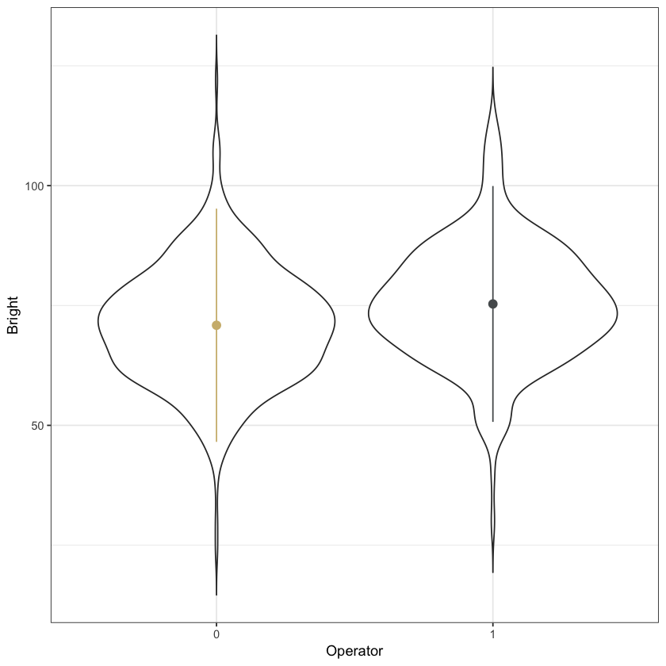

```r
library(faraway)

summary(glmod_pima)
test1 = as.factor(pima$test)
p = ggplot(pima, aes(x = test1, y = diastolic))  + #geom_boxplot(aes(x = group , y = weight))
    geom_violin(trim = FALSE) +
    #geom_boxplot(width = 0.1, alpha = 0.5, fill = c('#CFB87C', '#565A5C', "A2A4A3", 'blue')) +
    stat_summary(fun.data = mean_sdl, color = c('#CFB87C', '#565A5C')) +
    xlab("Operator") + ylab("Bright") +
    theme_bw();
p

anova(lm(diastolic ~ test, pima))
```

If we look at the `anova` function with `lm(diastolic ~ test)` we see the p-value is lower than $\alpha = 0.05$ therefore high diastolic pressure does affect your test. So, yes, women who test positive have higher diastolic blood pressure. Also, looking at the graph above we see the women who test position have a slight increase in diastolic blood pressure.

Looking at our regression model from part (A) diastoloc blood pressure is not significant in people who test positive. We see that the p-value is greater than $\alpha$.

The reason why these answers contradict each other is becuase the first question is asking about women who test positive only with respect to diastolic pressure. The `anova` function is only considering test towards diastolic and no other variables. The second is asking about the model which considers all varaibles that affect test.

**B.3 (e) (7 points) Ethical Issues in Data Collection**

Read Maya Iskandarani's [piece](https://researchblog.duke.edu/2016/10/24/diabetes-and-privacy-meet-big-data/) on consent and privacy concerns raised by this dataset. Summarize those concerns here.

The main concerns raised by this dataset is the ethical accessibility of personal information such as blood pressure, pregancy, and BMI in the PIMA Native Americans. And from that concern arises issue of "eternal" medical consent: your data being available perpetually in the future for. I agree with her concern that we as an individual and society must be wary of what consent and privacy terms we agree to.

When it comes to social media - Facebook, Instagram, Twitter - we don't realize that we sign our virtual privacy rights away to companies, to use our data for prediction and optimization. What Dr. Iskandarani spoke about is now a new issue that I was not aware of: "eternal" consent. In this article she speaks about "eternal" medical consent but, I bet, social media companies do this too.

In terms of the PIMA dataset its unfortunate that researches test predictions and ML models on personal citizenz dataset without there knowlegde. We should learn from these mistakes and make sure future medical organizations (and tech companies) do not use are data unethically.